# Grouping and summarizing

## Summarizing the median life expectancy

Si deseamos conocer la esperanza de vida promedio o la població total en un conjunto de observaciones, podemos hacer uso de la funciones **mean()** y **sum()** junto con **summarize()**. Por otro lado podemos también hacer uso de la función **median()** ya que esta función es robusta a **outliers**.

```r
library(dplyr)
library(gapminder)
#A continuación vamos a proceder a encontran la mediana de la esperanza de vida de nuestro conjunto de datos
gapminder %>% summarize(medianlifeExp = median(lifeExp))
```

| medianlifeExp |
| --- |
| 60.7125 |

## Summarizing the median life expectancy in 1957

También podemos combinar **summarize()** con **filter()** para encontrar la mediana de un año en concreto.

```r
gapminder %>% filter(year == 1957) %>% summarize(medianLifeExp = median(lifeExp))
```

| medianLifeExp |
| --- |
| 48.3605 |

## Summarizing multiple variables in 1957

Mediante **summarize()** podemos resumir múltiples variables de forma simultánea.

```r
#Filtramos para el año 1957 y aplicamos summarize para calcula la mediana de la esperanza de vida y el máximo de la renta per
#capita para dicho año
gapminder %>% filter(year == 1957) %>% summarize(medianLifeExp = median(lifeExp), maxGDP = max(gdpPercap))
```

| medianLifeExp | maxGDP |
| --- | --- |
| 48.3605 | 113523.1 |

## Summarizing by year

Hasta ahora hemos visto como resumir la información para un año concreto, sin embargo, si deseamos conocer dicha información para cada uno de los años podemos hacer uso de **group_by**.

```r
#Calculamos la mediana de la esperanza de vida y el máximo de la renta per capita para cada año
gapminder %>% group_by(year) %>% summarize(medianLifeExp = median(lifeExp), maxGDP = max(gdpPercap))
```

| year | medianLifeExp | maxGDP |
| --- | --- | --- |
| 1952 | 45.1355 | 108382.35 |
| 1957 | 48.3605 | 113523.13 |
| 1962 | 50.8810 | 95458.11 |
| 1967 | 53.8250 | 80894.88 |
| 1972 | 56.5300 | 109347.87 |
| 1977 | 59.6720 | 59265.48 |
| 1982 | 62.4415 | 33693.18 |
| 1987 | 65.8340 | 31540.97 |
| 1992 | 67.7030 | 34932.92 |
| 1997 | 69.3940 | 41283.16 |

[output cut: 2 more lines]

## Summarizing by continent

También podemos combinar **filter()** y **group_by()** para por ejemplo encontrar la mediana de la esperanza de vida y el máximo de la renta per capita para cada continente en el año 1957.

```r
#Obtenemos la mediana de la esperanza de vida y el máximo de la renta per capita para cada continente en el año 1957
gapminder %>% filter(year == 1957) %>% group_by(continent) %>% summarize(medianLifeExp = median(lifeExp), maxGDP = max(gdpPercap))
```

| continent | medianLifeExp | maxGDP |
| --- | --- | --- |
| Africa | 40.5925 | 5487.104 |
| Americas | 56.0740 | 14847.127 |
| Asia | 48.2840 | 113523.133 |
| Europe | 67.6500 | 17909.490 |
| Oceania | 70.2950 | 12247.395 |

## Summarizing by continent and year

Podemos agrupar por múltiples variables, por ejemplo, podemos agrupar de una sola tacada por año y continente.

```r
#Agrupamos de una sola tacada por año y continente y calculamos la mediana de la esperanza de vida y el máximo de la renta per
#capita
gapminder %>% group_by(year, continent) %>% summarize(medianLifeExp = median(lifeExp), maxGdpPercap = max(gdpPercap))
```

| year | continent | medianLifeExp | maxGdpPercap |
| --- | --- | --- | --- |
| 1952 | Africa | 38.8330 | 4725.296 |
| 1952 | Americas | 54.7450 | 13990.482 |
| 1952 | Asia | 44.8690 | 108382.353 |
| 1952 | Europe | 65.9000 | 14734.233 |
| 1952 | Oceania | 69.2550 | 10556.576 |
| 1957 | Africa | 40.5925 | 5487.104 |
| 1957 | Americas | 56.0740 | 14847.127 |
| 1957 | Asia | 48.2840 | 113523.133 |
| 1957 | Europe | 67.6500 | 17909.490 |
| 1957 | Oceania | 70.2950 | 12247.395 |

[output cut: 50 more lines]

## Visualizing median life expectancy over time

A continuación vamos a proceder a visualizar los datos sumarizados. En este caso vamos a proceder a representar como ha evolucionado la esperanza de vida a lo largo de los años.

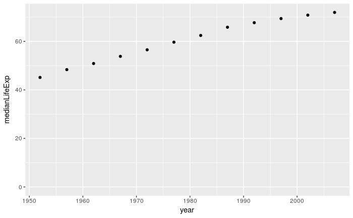

```r
library(ggplot2)
#Nos creamos nuestro conjunto de datos
by_year <- gapminder %>% group_by(year) %>% summarize(medianLifeExp = median(lifeExp), maxGDP = max(gdpPercap))
#Nos creamos el scatter plot
ggplot(by_year, aes(x = year, y = medianLifeExp)) + geom_point() + expand_limits(y = 0)
```

## Visualizing median GDP per capita per continent over time

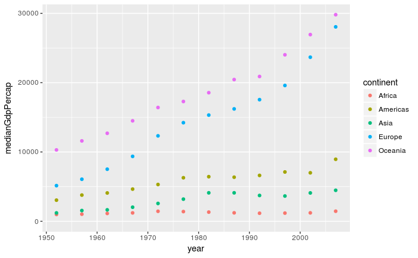

```r
#Nos creamos nuestro conjunto de datos
by_year_continent <- gapminder %>% group_by(continent, year) %>% summarize(medianGdpPercap = median(gdpPercap))
#Hacemos el grafo
ggplot(by_year_continent, aes(x = year, y = medianGdpPercap, color = continent)) + geom_point() + expand_limits(y = 0)
```

## Comparing median life expectancy and median GDP per continent in 2007

A continuación vamos a comparar para cada continente la relación entre la mediana de la renta per capita y la mediana de la esperanza de vida para el año 2007

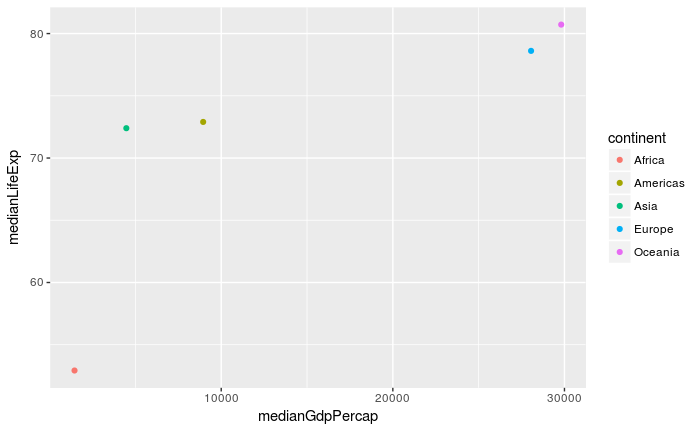

```r
#Nos creamos el dataset
by_continent_2007 <- gapminder %>% filter(year == 2007) %>% group_by(continent) %>% summarize(medianLifeExp = median(lifeExp), medianGdpPercap = median(gdpPercap))
#Hacemos el grafo
ggplot(by_continent_2007, aes(x = medianGdpPercap, y = medianLifeExp, color = continent)) + geom_point()
```